# Course Project - Practical Machine Learning - Jiayun Ni

Jiayun Ni

2019/3/20

# Overview

# Data Exploration and Data Slicing

I first load in the training dataset and testing dataset. From the raw data we would notice that many of the columns contains missing values so they might not be taken into consideration. Also, the original training dataset is splitted into two parts, one part of it would be used as training set for model training, another part of it would be used asmodel prediction validation.

```r
setwd("/Users/jiayunni/Desktop/njy/college/R/Practical Machining Learning")
traindata = read.csv("pml-training.csv",header = T)
testdata = read.csv("pml-testing.csv",header = T)
a1 = c(1:10,36:48,59:67,83:85,101,112:123,139,150:159)
a = c(1,a1+1)
t1 = traindata[,a]
library(caret)
set.seed(12)
inTrain = createDataPartition(y = t1[,1],p=0.7,list = FALSE)
data.train = t1[inTrain,-1]
data.validation = t1[-inTrain,-1]
t2 = testdata[,a]
data.test = t2[,-1]
```

# Model Establishment

I use several methods to train the model and use validation dataset to test the accuracy of the models. Finally I would select the most accurate model to predict the testing dataset. Since the classification is not binary so some methods for binary classification could not be used any more.

```r
set.seed(12)
```

## Decision Tree

```r
mod1 = train(classe~.,data = data.train,method = "rpart")
library(rattle)
```

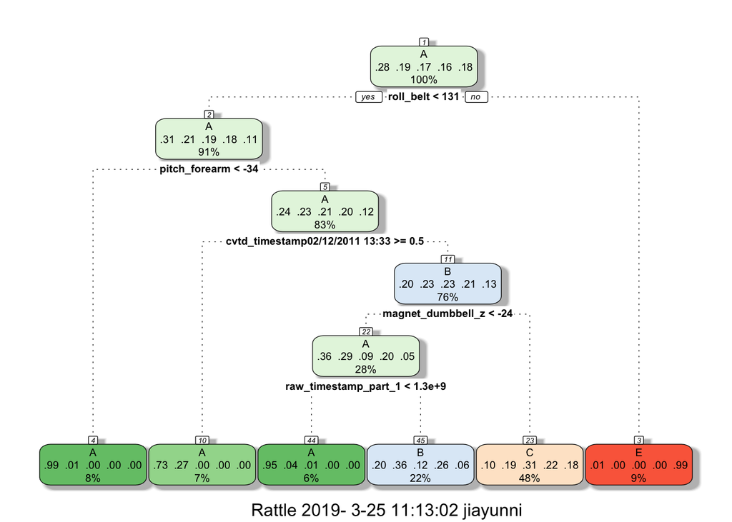

```r
fancyRpartPlot(mod1$finalModel)
```

```r
pred1 = predict(mod1, newdata = data.validation)
t1 = table(pred1, data.validation$classe)
t1
```

```
##
## pred1    A    B    C    D    E
##     A 1099   93    0    0    0
##     B  280  467  158  337   99
##     C  295  570  868  635  510
##     D    0    0    0    0    0
##     E    1    0    0    0  472
```

```r
tp1 = sum(diag(t1))/sum(t1)
tp1
```

```
## [1] 0.4938817
```

## Conditional Tree

```r
library(party)
mod2 = ctree(classe~.,data = data.train)
pred2 = predict(mod2,newdata = data.validation)
t2 = table(pred2, data.validation$classe)
t2
```

```
##
## pred2    A    B    C    D    E
##     A 1624   36    1    0    0
##     B   48 1057   31    2    0
##     C    3   37  978   18    7
##     D    0    0   12  929   35
##     E    0    0    4   23 1039
```

```r
tp2 = sum(diag(t2))/sum(t2)
tp2
```

```
## [1] 0.9563222
```

## GradientBboosting Machine (GBM)

```r
t3 = table(pred3, data.validation$classe)
t3
```

```
##
## pred3    A    B    C    D    E
##     A 1675    3    0    0    0
##     B    0 1123    0    0    0
##     C    0    4 1023    1    0
##     D    0    0    3  968    1
##     E    0    0    0    3 1080
```

```r
tp3 = sum(diag(t3))/sum(t3)
tp3
```

```
## [1] 0.9974507
```

```r
# very good
```

## Random Forest

```r
#mod4 = train(classe~., data = data.train,method = "rf")
#pred4 = predict(mod4,newdata = data.validation)
#t4 = table(pred4,data.validation$classe)
#t4
#tp4 = sum(diag(t4))/sum(t4)
#tp4
```

## Latent Dirichlet Allocation (LDA)

```r
t5 = table(pred5, data.validation$classe)
t5
```

```
##
## pred5    A    B    C    D    E
##     A 1512  112    0    0    0
##     B  133  862  106    2    0
##     C   29  146  887   93    6
##     D    0   10   32  818  108
##     E    1    0    1   59  967
```

```r
tp5 = sum(diag(t5))/sum(t5)
tp5
```

```
## [1] 0.8575799
```

## QDA

```r
#mod6 = train(classe~., data = data.train, method = "qda")
#pred6 = predict(mod6, newdata = data.validation)
#t6 = table(pred6, data.validation$classe)
#t6
#tp6 = sum(diag(t6))/sum(t6)
#tp6
```

## LDA + CV

I use a looping to test the best folds for lda method.

[output not shown]

```r
tr
```

```
##  [1] 0.8575799 0.8575799 0.8575799 0.8575799 0.8575799 0.8575799 0.8575799
##  [8] 0.8575799 0.8575799 0.8575799
```

## Random Forest + Cross Validation

```r
mod8 = train(classe~.,data = data.train, method = "rf",trControl = trainControl(method = "cv"),number = 3)
pred8 = predict(mod8,newdata = data.validation)
t8 = table(pred8,data.validation$classe)
t8
```

```
##
## pred8    A    B    C    D    E
##     A 1675    0    0    0    0
##     B    0 1130    0    0    0
##     C    0    0 1026    0    0
##     D    0    0    0  971    0
##     E    0    0    0    1 1081
```

```r
tp8 = sum(diag(t8))/sum(t8)
tp8
```

```
## [1] 0.99983
```

```r
# best , follow by gbm
```

## KNN

```r
mod9 = train(classe~.,data = data.train,method = "knn")
pred9 = predict(mod9, newdata = data.validation)
t9 = table(pred9, data.validation$classe)
t9
```

```
##
## pred9   A   B   C   D   E
##     A 749 340 326 247 287
##     B 221 229 140 159 193
##     C 286 201 257 178 163
##     D 210 177 150 228 197
##     E 209 183 153 160 241
```

```r
tp9 = sum(diag(t9))/sum(t9)
tp9
```

```
## [1] 0.2895989
```

## Naive Bayes

```r
t10 = table(pred10, data.validation$classe)
t10
```

```
##
## pred10    A    B    C    D    E
##      A 1584  219  107  209   87
##      B   23  744   49    0   87
##      C   51  159  870  176   48
##      D   17    8    0  559   24
##      E    0    0    0   28  835
```

```r
tp10 = sum(diag(t10))/sum(t10)
tp10
```

```
## [1] 0.7804215
```

## Combine Model for prediction

```r
compred1 = data.frame(pred1 = pred1,pred2 = pred2,pred3 = pred3,classe = data.validation$classe)
commod1 = train(classe~., data = compred1,method = "rf")
comPred1 = predict(commod1,newdata = data.validation)
tc1 = table(comPred1,data.validation$classe)
tc1
```

```
##
## comPred1    A    B    C    D    E
##        A 1675    3    0    0    0
##        B    0 1123    0    0    0
##        C    0    4 1023    1    0
##        D    0    0    3  968    1
##        E    0    0    0    3 1080
```

```r
tpc1 = sum(diag(tc1))/sum(tc1)
tpc1
```

```
## [1] 0.9974507
```

```r
compred2 = data.frame(pred1 = pred1,pred2 = pred2,classe = data.validation$classe)
commod2 = train(classe~., data = compred2,method = "rf")
comPred2 = predict(commod2,newdata = data.validation)
tc2 = table(comPred2,data.validation$classe)
tc2
```

```
##
## comPred2    A    B    C    D    E
##        A 1624   36    1    0    0
##        B   48 1057   31    2    0
##        C    3   37  978   18    3
##        D    0    0   12  929   31
##        E    0    0    4   23 1047
```

```r
tpc2 = sum(diag(tc2))/sum(tc2)
tpc2
```

```
## [1] 0.9576818
```

# Final Prediction for testing data

From the validation results above, I choose method of “GBM” and “Random Forest + Cross Validation” as final model for prediction since the accuracy of them ar the most accurate ones.

```r
pred.test.1 = predict(mod3,data.test)
pred.test.1
```

```
##  [1] B A B A A E D B A A B C B A E E A B B B
## Levels: A B C D E
```

```r
pred.test.2 = predict(mod8,data.test)
pred.test.2
```

```
##  [1] B A B A A E D B A A B C B A E E A B B B
## Levels: A B C D E
```